```r
suppressWarnings({
  library(tidyverse)
  library(ggpubr)
  library(MASS)
  library(rstatix)
  library(biotools)
  library(caret)
  library(nnet)
  library(pROC)
  library(ggplot2)
  library(corrr)
  library(ggcorrplot)
  library(FactoMineR)
})
```

[output not shown]

```r
dfc <- read.csv("C:/Users/Mathi/Documents/Studie/2 semester/ST514, DS805 Multivariat Statistisk Analyse/Projekt/winequality-red.csv",header = TRUE)

summary(dfc)
```

```
##  fixed.acidity   volatile.acidity  citric.acid    residual.sugar
##  Min.   : 4.60   Min.   :0.1200   Min.   :0.000   Min.   : 0.900
##  1st Qu.: 7.10   1st Qu.:0.3900   1st Qu.:0.090   1st Qu.: 1.900
##  Median : 7.90   Median :0.5200   Median :0.260   Median : 2.200
##  Mean   : 8.32   Mean   :0.5278   Mean   :0.271   Mean   : 2.539
##  3rd Qu.: 9.20   3rd Qu.:0.6400   3rd Qu.:0.420   3rd Qu.: 2.600
##  Max.   :15.90   Max.   :1.5800   Max.   :1.000   Max.   :15.500
##    chlorides       free.sulfur.dioxide total.sulfur.dioxide    density
##  Min.   :0.01200   Min.   : 1.00       Min.   :  6.00       Min.   :0.9901
##  1st Qu.:0.07000   1st Qu.: 7.00       1st Qu.: 22.00       1st Qu.:0.9956
##  Median :0.07900   Median :14.00       Median : 38.00       Median :0.9968
##  Mean   :0.08747   Mean   :15.87       Mean   : 46.47       Mean   :0.9967
##  3rd Qu.:0.09000   3rd Qu.:21.00       3rd Qu.: 62.00       3rd Qu.:0.9978
##  Max.   :0.61100   Max.   :72.00       Max.   :289.00       Max.   :1.0037
##        pH          sulphates         alcohol         quality
##  Min.   :2.740   Min.   :0.3300   Min.   : 8.40   Min.   :3.000
##  1st Qu.:3.210   1st Qu.:0.5500   1st Qu.: 9.50   1st Qu.:5.000
##  Median :3.310   Median :0.6200   Median :10.20   Median :6.000
##  Mean   :3.311   Mean   :0.6581   Mean   :10.42   Mean   :5.636
##  3rd Qu.:3.400   3rd Qu.:0.7300   3rd Qu.:11.10   3rd Qu.:6.000
##  Max.   :4.010   Max.   :2.0000   Max.   :14.90   Max.   :8.000
```

Create a new window to display the plots Loop through each column and create QQ plots

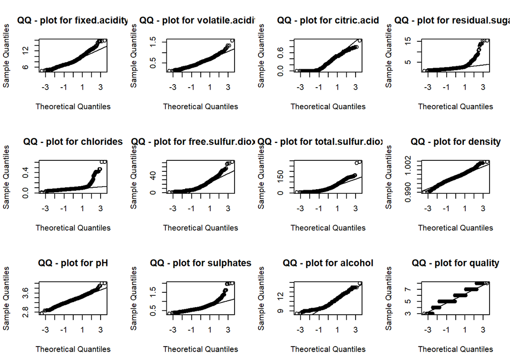

```r
par(mfrow = c(3, 4)) # Adjust the layout based on the number of columns in dfc
for (i in 1:ncol(dfc)) {
  qqnorm(dfc[,i], main = paste("QQ - plot for", colnames(dfc)[i]))
  qqline(dfc[,i])
}
```

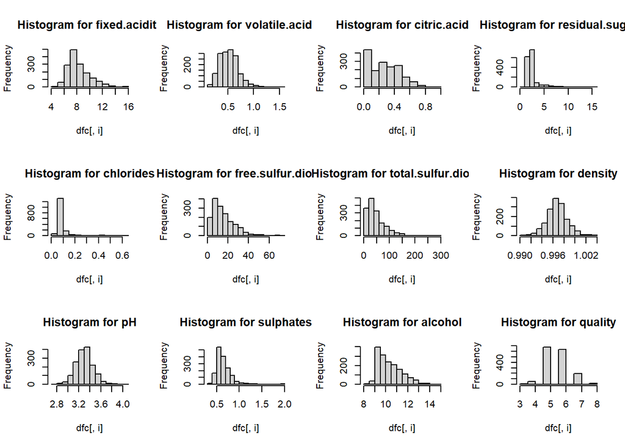

```r
for (i in 1:ncol(dfc)) {
  hist(dfc[, i], main = paste("Histogram for", colnames(dfc)[i]))
}
```

It does not seem as though, there are any variables, that are normally distributed however let us try with a shapiro test.

```r
shapiro_p_table <- data.frame(matrix(nrow = 1, ncol = ncol(dfc)))

colnames(shapiro_p_table) <- colnames(dfc)

for (i in 1:ncol(dfc)) {
  result <- shapiro.test(dfc[, i])
  shapiro_p_table[1, i] <- result$p.value
}

print(shapiro_p_table)
```

```
##   fixed.acidity volatile.acidity  citric.acid residual.sugar    chlorides
## 1  1.525012e-24     2.692935e-16 1.021932e-21   1.020162e-52 1.179056e-55
##   free.sulfur.dioxide total.sulfur.dioxide      density           pH
## 1        7.694597e-31         3.573451e-34 1.936053e-08 1.712237e-06
##     sulphates      alcohol      quality
## 1 5.82314e-38 6.644057e-27 9.515085e-36
```

We see that none are normally distributed

We decide that quality can be put into two groups Not great and Great.

```r
dfc$grade <- case_when(dfc$quality <= 6 ~ "Not great",
                       dfc$quality > 6 ~ "Great")
```

We would like to check for homogeneity of covariance matrices, since that and the type of distribution have much to say about which classification methods that we are going to use.

```r
box_m(dfc[,1:11],dfc[,"grade"])
```

```
## # A tibble: 1 × 4
##   statistic  p.value parameter method
##       <dbl>    <dbl>     <dbl> <chr>
## 1      355. 3.16e-41        66 Box's M-test for Homogeneity of Covariance Matri…
```

We see that the p-value is belov 0.05, in which case we must reject the null-hypthosis. There are at least two variables that do not have homogeneity of covariance matrices.

However

```r
box_m(dfc[, c(1, 2, 3, 4, 6,7,8,9,10)], dfc[,"grade"])
```

```
## # A tibble: 1 × 4
##   statistic  p.value parameter method
##       <dbl>    <dbl>     <dbl> <chr>
## 1      189. 1.45e-19        45 Box's M-test for Homogeneity of Covariance Matri…
```

and

```r
box_m(dfc[, c(1, 2, 3, 4, 6,7,8,9,10,11)], dfc[,"grade"])
```

```
## # A tibble: 1 × 4
##   statistic  p.value parameter method
##       <dbl>    <dbl>     <dbl> <chr>
## 1      260. 2.52e-28        55 Box's M-test for Homogeneity of Covariance Matri…
```

```r
dfc_for_model <- dfc[, c(1, 2, 3, 4, 6,7,8,9,10)]
dfc_for_model$grade <- dfc$grade
```

```r
training.individuals <- createDataPartition(dfc_for_model$grade, p = 0.8, list = FALSE)

train.data <- dfc_for_model[training.individuals, ]
test.data <- dfc_for_model[-training.individuals, ]
test.data$grade <- as.factor(test.data$grade)
train.data$grade <- as.factor(train.data$grade)
```

LDA model

```r
LDA_model <- lda(grade ~. ,data =train.data )
LDA_model
```

```
## Call:
## lda(grade ~ ., data = train.data)
##
## Prior probabilities of groups:
##     Great Not great
## 0.1359375 0.8640625
##
## Group means:
##           fixed.acidity volatile.acidity citric.acid residual.sugar
## Great          8.868391        0.4102586   0.3808046       2.726149
## Not great      8.205606        0.5501266   0.2481736       2.484629
##           free.sulfur.dioxide total.sulfur.dioxide   density       pH sulphates
## Great                14.39943             35.16667 0.9960107 3.282874 0.7462644
## Not great            16.06826             47.94213 0.9968274 3.315009 0.6409494
##
## Coefficients of linear discriminants:
##                                LD1
## fixed.acidity         -0.609764268
## volatile.acidity       1.170030398
## citric.acid           -1.005175075
## residual.sugar        -0.350758796
## free.sulfur.dioxide    0.001530779
## total.sulfur.dioxide   0.005449923
## density              642.928506562
## pH                    -2.621996373
## sulphates             -2.633079555
```

```r
predictions <- LDA_model %>% predict(test.data)


mean(predictions$class==test.data$grade)
```

```
## [1] 0.8526646
```

Logistic Regression

```r
LR_model <- glm(grade ~., data = train.data, family = binomial)


predictions <- predict(LR_model, newdata = test.data, type = "response")

predicted_classes <- ifelse(predictions > 0.5, "Not great", "Great")

mean(predicted_classes == test.data$grade)
```

```
## [1] 0.8589342
```

ROC -curve

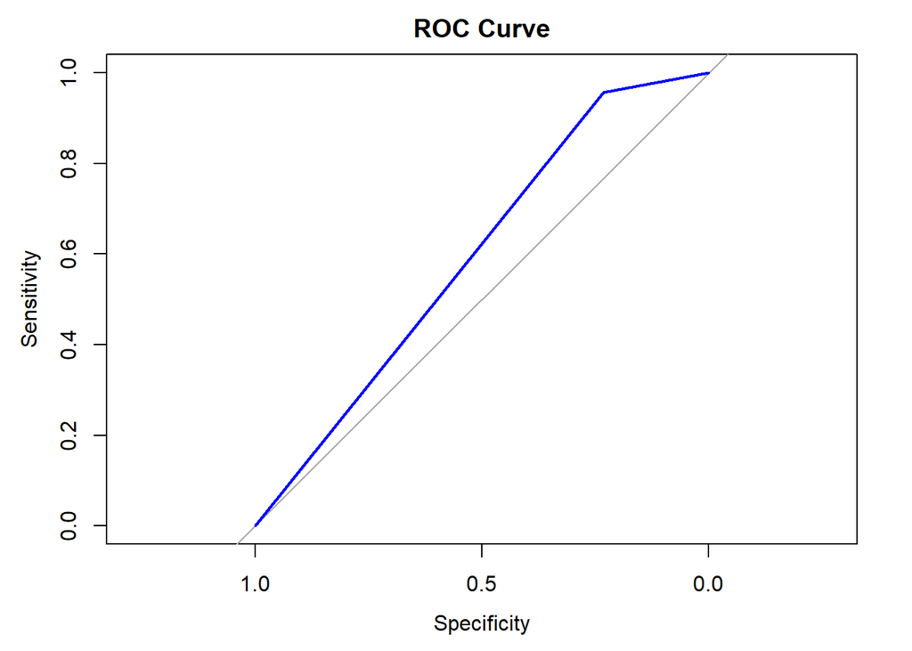

```r
test.data$predicted = predicted_classes

roc_curve <- roc(ifelse(test.data$grade == "Not great", 1, 0), ifelse(predicted_classes == "Not great", 1, 0))
plot(roc_curve, main = "ROC Curve", col = "blue")
```

Check for sensitivity and other interesting parameters using LDA.

```r
predictions <- LDA_model %>% predict(dfc)


predicted_classes <-predictions[["class"]]

dfc$predicted <-predicted_classes
dfc$predicted <- as.factor(dfc$predicted)
dfc$grade <- as.factor(dfc$grade)
conf_matrix <- confusionMatrix(dfc$predicted, dfc$grade)
```

```r
conf_matrix[["byClass"]]
```

```
##          Sensitivity          Specificity       Pos Pred Value
##           0.39631336           0.94934877           0.55128205
##       Neg Pred Value            Precision               Recall
##           0.90921691           0.55128205           0.39631336
##                   F1           Prevalence       Detection Rate
##           0.46112601           0.13570982           0.05378361
## Detection Prevalence    Balanced Accuracy
##           0.09756098           0.67283107
```

We will now try with three categories and see what happens

```r
dfc$grade <- case_when(dfc$quality <= 4 ~ "bad",
                       dfc$quality > 4 & dfc$quality <= 6 ~ "okay",
                       dfc$quality > 6 ~ "Great")
dfc <- dfc[,-12]
box_m(dfc[,1:11],dfc[,"grade"])
```

```
## # A tibble: 1 × 4
##   statistic  p.value parameter method
##       <dbl>    <dbl>     <dbl> <chr>
## 1      538. 1.70e-50       132 Box's M-test for Homogeneity of Covariance Matri…
```

```r
numeric_cols <- sapply(dfc, is.numeric)
min_max_scale <- function(x) {
  (x - min(x, na.rm = TRUE)) / (max(x, na.rm = TRUE) - min(x, na.rm = TRUE))
}

dfc[numeric_cols] <- lapply(dfc[numeric_cols], min_max_scale)
```

We can see that there are atleast two variables, that still do not have the same covariance matrices

We also try to see if there are some subsets of size >3, where they have the same covariance, but we were not able to find such a thing.

Therefor we have to conclude, that with our three class’ there are no homogeneity and the data is not normaly distributed, so we will use a logistic regression to predict.

We will do as we did before

```r
training.individuals <- createDataPartition(dfc$grade, p = 0.8, list = FALSE)

train.data <- dfc[training.individuals, ]
test.data <- dfc[-training.individuals, ]
test.data$grade <- as.factor(test.data$grade)
train.data$grade <- as.factor(train.data$grade)
```

```r
model <- multinom(grade ~ ., data = train.data)
predictions <- predict(model, newdata = test.data, type = "class")

test.data$predicted <-predictions



correct_predictions <- sum(predictions == test.data$grade)
```

Calculate total number of predictions

```r
total_predictions <- length(predictions)
```

Calculate accuracy

```r
accuracy <- correct_predictions / total_predictions
```

Print accuracy

```r
cat("Accuracy:", accuracy)
```

```
## Accuracy: 0.8333333
```

𝐸(APER)

```r
aer(test.data$grade,test.data$predicted)
```

```
## [1] 0.1666667
```

analysis of how well the models did

```r
predictions <- predict(model, newdata = dfc, type = "class")

dfc$predicted <-predictions
dfc$predicted <- as.factor(dfc$predicted)
dfc$grade <- as.factor(dfc$grade)
```

Create a confusion matrix for predicted vs. grade

```r
conf_matrix <- confusionMatrix(dfc$predicted, dfc$grade)

conf_matrix[["byClass"]]
```

```
##              Sensitivity Specificity Pos Pred Value Neg Pred Value Precision
## Class: bad    0.06349206   0.9980469      0.5714286      0.9629397 0.5714286
## Class: Great  0.32718894   0.9638205      0.5867769      0.9012179 0.5867769
## Class: okay   0.96057619   0.2714286      0.8613188      0.5937500 0.8613188
##                  Recall        F1 Prevalence Detection Rate
## Class: bad   0.06349206 0.1142857 0.03939962    0.002501563
## Class: Great 0.32718894 0.4201183 0.13570982    0.044402752
## Class: okay  0.96057619 0.9082437 0.82489056    0.792370231
##              Detection Prevalence Balanced Accuracy
## Class: bad            0.004377736         0.5307695
## Class: Great          0.075672295         0.6455047
## Class: okay           0.919949969         0.6160024
```

We now want to visualize our grouping. However as we have a mutlivariate dataset, we need to reduce the number of dimensions. We will do that using PCA and choosing the two first components as our x and y axis for our plot point.

We choose only the numerical data and scale it.

```r
numerical_data <- dfc[,1:11]
data_normalized <- scale(numerical_data)
```

After that we create a correlation matrix

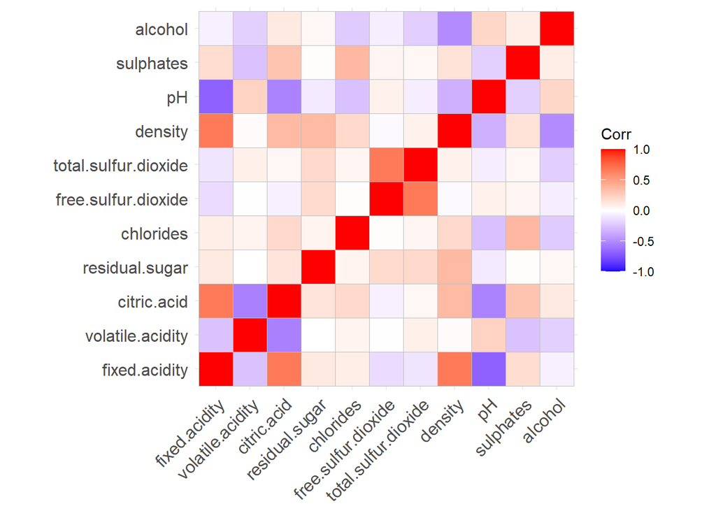

```r
corr_matrix <- cor(data_normalized)
ggcorrplot(corr_matrix)
```

Now we begin the PCA

```r
data.pca <- princomp(corr_matrix)
summary(data.pca)
```

```
## Importance of components:
##                           Comp.1    Comp.2    Comp.3     Comp.4     Comp.5
## Standard deviation     0.8863301 0.5394784 0.4428586 0.36479383 0.24080774
## Proportion of Variance 0.5093850 0.1887136 0.1271702 0.08628796 0.03760071
## Cumulative Proportion  0.5093850 0.6980987 0.8252689 0.91155684 0.94915756
##                            Comp.6    Comp.7      Comp.8      Comp.9
## Standard deviation     0.19870623 0.1553799 0.104800720 0.054764047
## Proportion of Variance 0.02560225 0.0156547 0.007121701 0.001944672
## Cumulative Proportion  0.97475981 0.9904145 0.997536214 0.999480885
##                             Comp.10 Comp.11
## Standard deviation     0.0282946318       0
## Proportion of Variance 0.0005191147       0
## Cumulative Proportion  1.0000000000       1
```

```r
data.pca$loadings[, 1:2]
```

```
##                           Comp.1      Comp.2
## fixed.acidity         0.50027954  0.01955042
## volatile.acidity     -0.27610724 -0.31233268
## citric.acid           0.46160865  0.17294502
## residual.sugar        0.07639678 -0.17734895
## chlorides             0.17482567 -0.14002245
## free.sulfur.dioxide  -0.12807537 -0.34909047
## total.sulfur.dioxide -0.06665915 -0.45032318
## density               0.36328372 -0.33657693
## pH                   -0.46316403  0.11347184
## sulphates             0.20716525  0.15141492
## alcohol              -0.11722620  0.58936887
```

```r
pca_1_2 <-data.pca$loadings[, 1:2]
pca_1_2<-as.matrix(pca_1_2)
numerical_data<-as.matrix(numerical_data)
```

We multiply the numerical_data with our first and second pricipal components

```r
reduced_data<-numerical_data %*%pca_1_2
reduced_data<-as.data.frame(reduced_data)
reduced_data$predicted <- dfc$predicted
reduced_data$true_class <- dfc$grade
```

```r
library(gridExtra)
```

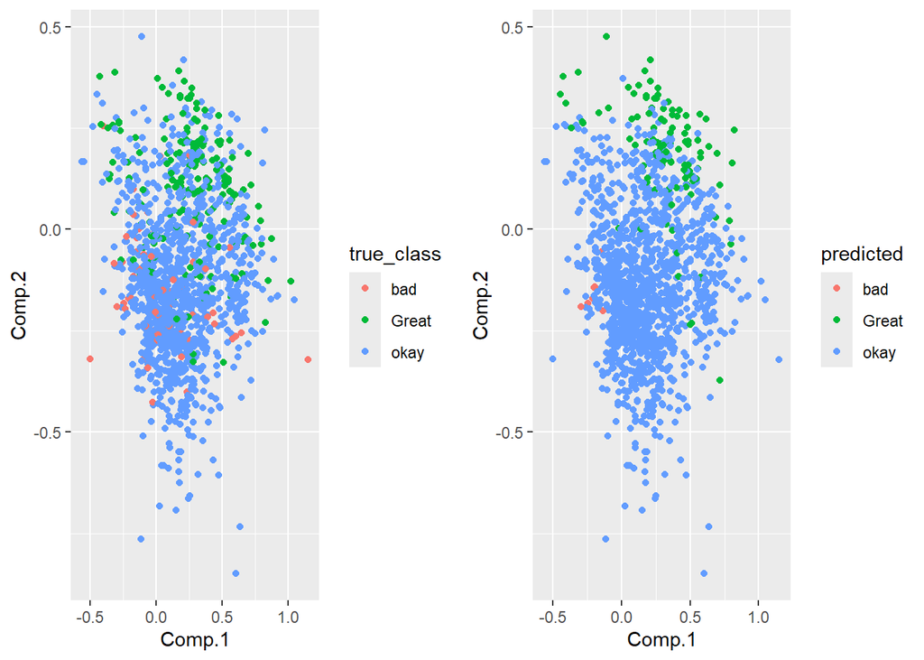

```r
plot1 <- ggplot(reduced_data, aes(x = Comp.1, y = Comp.2, colour = true_class)) +
  geom_point()

plot2 <- ggplot(reduced_data, aes(x = Comp.1, y = Comp.2, colour = predicted)) +
  geom_point()

grid.arrange(plot1, plot2, ncol = 2)
```